# Resume ATS Scanner_Project

```python
import pandas as pd
import numpy as np
import matplotlib.pyplot as plt
import re
from datetime import datetime
import seaborn as sns
```

```python
resume_df= pd.read_csv("Resume.csv")
resume_df.describe()
```

|  | ID |
| --- | --- |
| count | 2.484000e+03 |
| mean | 3.182616e+07 |
| std | 2.145735e+07 |
| min | 3.547447e+06 |
| 25% | 1.754430e+07 |
| 50% | 2.521031e+07 |
| 75% | 3.611444e+07 |
| max | 9.980612e+07 |

```python
resume_df.head()
```

|  | ID | Resume_str | Resume_html | Category |
| --- | --- | --- | --- | --- |
| 0 | 16852973 | HR ADMINISTRATOR/MARKETING ASSOCIATE\... | <div class="fontsize fontface vmargins hmargin... | HR |
| 1 | 22323967 | HR SPECIALIST, US HR OPERATIONS ... | <div class="fontsize fontface vmargins hmargin... | HR |
| 2 | 33176873 | HR DIRECTOR Summary Over 2... | <div class="fontsize fontface vmargins hmargin... | HR |
| 3 | 27018550 | HR SPECIALIST Summary Dedica... | <div class="fontsize fontface vmargins hmargin... | HR |
| 4 | 17812897 | HR MANAGER Skill Highlights ... | <div class="fontsize fontface vmargins hmargin... | HR |

```python
resume_df.info()
```

```
<class 'pandas.core.frame.DataFrame'>
RangeIndex: 2484 entries, 0 to 2483
Data columns (total 4 columns):
 #   Column       Non-Null Count  Dtype
---  ------       --------------  -----
 0   ID           2484 non-null   int64
 1   Resume_str   2484 non-null   object
 2   Resume_html  2484 non-null   object
 3   Category     2484 non-null   object
dtypes: int64(1), object(3)
memory usage: 77.8+ KB
```

```python
resume_df.isnull()
```

|  | ID | Resume_str | Resume_html | Category |
| --- | --- | --- | --- | --- |
| 0 | False | False | False | False |
| 1 | False | False | False | False |
| 2 | False | False | False | False |
| 3 | False | False | False | False |
| 4 | False | False | False | False |
| ... | ... | ... | ... | ... |
| 2479 | False | False | False | False |
| 2480 | False | False | False | False |
| 2481 | False | False | False | False |
| 2482 | False | False | False | False |
| 2483 | False | False | False | False |

2484 rows × 4 columns

```python
resume_df.isnull().sum()
```

```
ID             0
Resume_str     0
Resume_html    0
Category       0
dtype: int64
```

```python
import re
import pandas as pd
from datetime import datetime

resume_df = pd.read_csv("Resume.csv")

# Initialize an empty list to store dictionaries
data = []

# Function to extract data using regex
def extract_data(pattern, text):
    match = re.search(pattern, text, re.DOTALL)
    return match.group(0).strip() if match else ""

# Function to extract experience length using regex
def extract_experience_length(resume):
    # Define regex pattern to capture date ranges
    date_pattern = r'(\b\w{3}\s\d{4})\s+to\s+(\b\w{3}\s\d{4}|\bCurrent\b)'

    # Find all date ranges in the resume string
    date_ranges = re.findall(date_pattern, resume)

    total_months = 0

    for start_date, end_date in date_ranges:
        # Convert start date to datetime
        start_date_dt = datetime.strptime(start_date, '%b %Y')

        if end_date == 'Current':
            end_date_dt = datetime.now()
        else:
            # Convert end date to datetime
            end_date_dt = datetime.strptime(end_date, '%b %Y')

        # Calculate difference in months
        months_diff = (end_date_dt.year - start_date_dt.year) * 12 + (end_date_dt.month - start_date_dt.month)
        total_months += months_diff

    # Convert total months to years and months
    years = total_months // 12
    months = total_months % 12

    return f"{years} years, {months} months"

# Parse each row of the DataFrame and add to the list
for index, row in resume_df.iterrows():
    resume_number = row['ID']
    resume_str = str(row['Resume_str'])  # Convert to string

    # Extract information from resume_str

    _qualifications = extract_data(r"\b(?:Certified|Certification|Awarded|Accomplished).*?(\w[\w\s-]*?\b(?:Certification|Certified|Scholarship|Trainer)\b)", resume_str)
    experience_length = extract_experience_length(resume_str)

    awards = extract_data(r'Awards?\s+(.+?)\s+(?:Community Service|Volunteering|Driver(?:\'s)? License Availability|Skills|Languages|$)', resume_str)
    awards_2 = bool(awards)  # Convert to boolean

    community_service = extract_data(r'Community Service\s+(.+?)\s+(?:Awards?|Volunteering|Driver(?:\'s)? License Availability|Skills|Languages|$)', resume_str)
    community_service_2 = bool(community_service)  # Convert to boolean

    volunteering = extract_data(r'Volunteering\s+(.+?)\s+(?:Awards?|Community Service|Driver(?:\'s)? License Availability|Skills|Languages|$)', resume_str)
    volunteering_2 = bool(volunteering)  # Convert to boolean

    drivers_license_availability = extract_data(r'Driver(?:\'s)? License Availability\s+|(Yes|No)', resume_str)
    drivers_license_availability_2 = bool(drivers_license_availability)  # Convert to boolean

    skills = extract_data(r'Skills\s+(.+?)\s+(?:Awards?|Community Service|Volunteering|Driver(?:\'s)? License Availability|Languages|$)', resume_str)
    skills_count = len(skills.split(',')) if skills else 0
    languages = extract_data(r'Languages\s+(.+?)\s+(?:Awards?|Community Service|Volunteering|Driver(?:\'s)? License Availability|Skills|$)', resume_str)

    education_type_pattern = extract_data(r'(?:Bachelor|Master|PhD|Doctorate|Diploma|Certificate)', resume_str)
    school_type_pattern = extract_data(r'(?:University|College|High School)', resume_str)
    education_major_pattern = extract_data(r'Major\s*:\s*([^\n\r]*)', resume_str)

    # Append the parsed data to the list as a dictionary
    data.append({
        'RESUME_NUMBER': resume_number,
        'QUALIFICATIONS': _qualifications,
        'EDUCATION_TYPE': education_type_pattern,
        'SCHOOL_TYPE':  school_type_pattern,
        'EDUCATION_MAJOR': education_major_pattern,
        'EXPERIENCE_LENGTH': experience_length,
        'AWARDS': awards_2,
        'COMMUNITY_SERVICE': community_service_2,
        'VOLUNTEERING': volunteering_2,
        'DRIVERS_LICENSE_AVAILABILITY': drivers_license_availability_2,
        'SKILLS_COUNT': skills_count,
        'SKILLS': skills,
        'LANGUAGES': languages
    })

# Create a DataFrame from the list of dictionaries
task1_done1_df = pd.DataFrame(data)

# Save Task1Done1.csv
task1_done1_df.to_csv("Task1Done1.csv", index=True)
```

```python
task1_done1_df.info()
```

```
<class 'pandas.core.frame.DataFrame'>
RangeIndex: 2484 entries, 0 to 2483
Data columns (total 13 columns):
 #   Column                        Non-Null Count  Dtype
---  ------                        --------------  -----
 0   RESUME_NUMBER                 2484 non-null   int64
 1   QUALIFICATIONS                2484 non-null   object
 2   EDUCATION_TYPE                2484 non-null   object
 3   SCHOOL_TYPE                   2484 non-null   object
 4   EDUCATION_MAJOR               2484 non-null   object
 5   EXPERIENCE_LENGTH             2484 non-null   object
 6   AWARDS                        2484 non-null   bool
 7   COMMUNITY_SERVICE             2484 non-null   bool
 8   VOLUNTEERING                  2484 non-null   bool
 9   DRIVERS_LICENSE_AVAILABILITY  2484 non-null   bool
 10  SKILLS_COUNT                  2484 non-null   int64
 11  SKILLS                        2484 non-null   object
 12  LANGUAGES                     2484 non-null   object
dtypes: bool(4), int64(2), object(7)
memory usage: 184.5+ KB
```

```python
task1_done1_df.describe()
```

|  | RESUME_NUMBER | SKILLS_COUNT |
| --- | --- | --- |
| count | 2.484000e+03 | 2484.000000 |
| mean | 3.182616e+07 | 36.620773 |
| std | 2.145735e+07 | 34.368996 |
| min | 3.547447e+06 | 0.000000 |
| 25% | 1.754430e+07 | 10.000000 |
| 50% | 2.521031e+07 | 30.500000 |
| 75% | 3.611444e+07 | 50.000000 |
| max | 9.980612e+07 | 274.000000 |

```python
task1_done1_df.head(40)
```

|  | RESUME_NUMBER | QUALIFICATIONS | EDUCATION_TYPE | SCHOOL_TYPE | EDUCATION_MAJOR | EXPERIENCE_LENGTH | AWARDS | COMMUNITY_SERVICE | VOLUNTEERING | DRIVERS_LICENSE_AVAILABILITY | SKILLS_COUNT | SKILLS | LANGUAGES |
| --- | --- | --- | --- | --- | --- | --- | --- | --- | --- | --- | --- | --- | --- |
| 0 | 16852973 | Certification Certified by IHG in Customer Lo... | Diploma | College |  | 23 years, 5 months | False | False | False | False | 36 | Skills Accounting, ads, advertising, analy... |  |
| 1 | 22323967 |  | Master | University |  | 0 years, 0 months | False | False | False | True | 40 | Skills Adobe Photoshop, ADP, Asset Manageme... |  |
| 2 | 33176873 |  | Master | University |  | 0 years, 0 months | False | False | False | False | 8 | Skills Recruiting FMLA/EEO/FLSA HR... |  |
| 3 | 27018550 |  | Certificate |  |  | 5 years, 11 months | False | False | False | False | 24 | Skills Type 50 wpm and 10-Key by touc... |  |
| 4 | 17812897 |  | Bachelor |  |  | 21 years, 4 months | False | False | False | True | 76 | Skills ADA, ADP, art, agency, benefits, Ben... |  |
| 5 | 11592605 |  | Certificate | University |  | 0 years, 0 months | False | False | False | True | 31 | Skills administrative, Administrative Assis... |  |
| 6 | 25824789 |  | Bachelor | University |  | 0 years, 0 months | True | False | False | True | 38 | Skills ADA, ADMINISTRATIVE SKILLS, administ... |  |
| 7 | 15375009 |  | Bachelor | University |  | 0 years, 0 months | False | False | False | True | 100 | Skills administrative, ADP, backup, Benefit... |  |
| 8 | 11847784 |  | Bachelor | University |  | 0 years, 0 months | False | False | False | False | 50 | Skills Management consultation Negot... |  |
| 9 | 32896934 |  | Bachelor | University |  | 0 years, 0 months | False | False | False | False | 60 | Skills and MRP Vacation Calendar). Provides a... |  |
| 10 | 29149998 |  |  | College |  | 0 years, 0 months | False | False | False | False | 45 | Skills Accounting, ADP, analytical skills, ... |  |
| 11 | 11480899 |  | Master | University |  | 0 years, 0 months | False | False | False | False | 42 | Skills Administrative, administrative suppo... |  |
| 12 | 23155093 |  |  | College |  | 0 years, 0 months | False | False | False | True | 16 | Skills Management, Administrative Support, ... | Languages Working knowledge of Spanish and ... |
| 13 | 11763983 |  | Bachelor | College |  | 22 years, 0 months | False | False | False | True | 23 | Skills ACA, ADP Payroll, AS400, benefits, ... |  |
| 14 | 27490876 |  | Certificate | University |  | 0 years, 0 months | False | False | False | True | 28 | Skills administrative, ad, arbitration, age... |  |
| 15 | 32977530 |  |  |  |  | 0 years, 0 months | False | False | False | False | 1 | Skills Accounts Payable Accounts Receivab... |  |
| 16 | 93002334 |  | Bachelor | University |  | 0 years, 0 months | False | False | False | True | 15 | Skills Systems: Excel, Outlook, Power Poin... |  |
| 17 | 24184357 |  |  | University |  | 0 years, 0 months | False | False | False | True | 147 | Skills\t\tGood Interpersonal Skills\t\tOrganiz... |  |
| 18 | 73077810 |  | Master | University |  | 0 years, 0 months | False | False | False | False | 27 | Skills ADP, benefits, closing, Coach, coach... |  |
| 19 | 13879043 |  | Bachelor | University |  | 0 years, 0 months | True | False | False | False | 30 | Skills benefits, budget, client, delivery, ... |  |
| 20 | 30163002 |  |  | University |  | 0 years, 0 months | False | False | False | True | 26 | Skills business development, central point ... |  |
| 21 | 18827609 |  | Bachelor | University |  | 0 years, 0 months | False | False | False | True | 88 | Skills Recruiting Onboarding Projec... |  |
| 22 | 25676643 |  | Bachelor | University |  | 0 years, 0 months | True | False | False | True | 16 | Skills HR Advisory Services Strategi... |  |
| 23 | 12786012 | Certified Human Resources Professional with ex... |  | University |  | 0 years, 0 months | False | False | False | True | 17 | Skills benchmarking, benefits, conflict res... |  |
| 24 | 87968870 |  |  | University |  | 0 years, 0 months | False | False | False | True | 23 | Skills ADA, ADP, benefits, clarify, employe... |  |
| 25 | 46258701 |  |  | University |  | 0 years, 0 months | False | False | False | False | 29 | Skills and Qualifications Microsoft Sharep... |  |
| 26 | 14225422 |  | Master |  |  | 0 years, 0 months | False | False | False | False | 33 | Skills ADP payroll, Attorney, benefits, bil... |  |
| 27 | 29297973 |  | Master | University |  | 0 years, 0 months | False | False | False | False | 80 | Skills On-boarding Staffing and rec... |  |
| 28 | 18334783 |  |  | University |  | 0 years, 0 months | False | False | False | False | 23 | Skills administrative, budget, contracts, c... |  |
| 29 | 19717385 |  | Master | University |  | 9 years, 1 months | False | False | False | True | 17 | Skills Microsoft Excel, Outlook, PowerPoi... |  |
| 30 | 49937469 |  |  | College |  | 7 years, 0 months | False | False | False | True | 38 | Skills academic, A.I., attention to detail,... |  |
| 31 | 18316239 |  |  |  |  | 0 years, 0 months | False | False | False | False | 47 | Skills ABC, ADP, ADR, benefits, Benefits Ad... |  |
| 32 | 17855844 | Accomplished HR Professional experienced in st... | Certificate | University |  | 0 years, 0 months | True | False | False | True | 50 | Skills ADA, administrative, Adobe Illustrat... |  |
| 33 | 57667857 | Certified Professionals in Human Resources Ass... | Bachelor | University |  | 0 years, 0 months | False | False | False | False | 33 | Skills ADA, advertisements, benefits, budg... |  |
| 34 | 17422560 |  |  | College |  | 0 years, 0 months | False | False | False | True | 35 | Skills cash receipts, cash handling, cash r... |  |
| 35 | 32947778 |  | Bachelor |  |  | 0 years, 0 months | False | False | False | True | 49 | Skills benefits, budget analysis, budgets,... |  |
| 36 | 23914451 |  | Bachelor | University |  | 9 years, 0 months | False | False | False | True | 35 | Skills Associate Relations, Audits, Asset ... |  |
| 37 | 21265194 |  | Master | University |  | 0 years, 0 months | True | False | False | True | 1 | Skills Title VII ADA Mid - Senior level... |  |
| 38 | 51769822 |  |  | University |  | 0 years, 0 months | False | False | False | False | 27 | Skills Office support: Accounting, bill... | Languages Fluent (speaking, reading, writi... |
| 39 | 19616406 |  | Certificate | University |  | 19 years, 0 months | False | False | False | True | 61 | Skills processing accounts payable, Adminis... |  |

```python
total= task1_done1_df['DRIVERS_LICENSE_AVAILABILITY'] == True
print(total)
```

```
0       False
1        True
2       False
3       False
4        True
        ...
2479     True
2480     True
2481    False
2482     True
2483     True
Name: DRIVERS_LICENSE_AVAILABILITY, Length: 2484, dtype: bool
```

Q1: Review the number of applicants for each position.

```python
category_counts = resume_df['Category'].value_counts()
print(category_counts)
```

```
Category
INFORMATION-TECHNOLOGY    120
BUSINESS-DEVELOPMENT      120
FINANCE                   118
ADVOCATE                  118
ACCOUNTANT                118
ENGINEERING               118
CHEF                      118
AVIATION                  117
FITNESS                   117
SALES                     116
BANKING                   115
HEALTHCARE                115
CONSULTANT                115
CONSTRUCTION              112
PUBLIC-RELATIONS          111
HR                        110
DESIGNER                  107
ARTS                      103
TEACHER                   102
APPAREL                    97
DIGITAL-MEDIA              96
AGRICULTURE                63
AUTOMOBILE                 36
BPO                        22
Name: count, dtype: int64
```

Q2: A concerned parents contacts you to tell them if there is a specific school type that would guaranteed for their child a good future if you can tell, and which is it ?

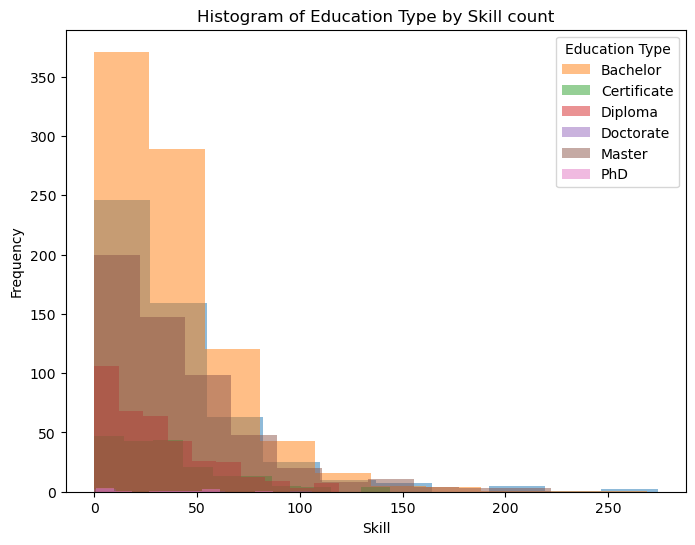

```python
# Extract relevant columns
education_skills_df = task1_done1_df[['EDUCATION_TYPE', 'SKILLS_COUNT']]

# Plotting the histogram
plt.figure(figsize=(8, 6))
education_skills_df.groupby('EDUCATION_TYPE')['SKILLS_COUNT'].plot(kind='hist', alpha=0.5, legend=True)
plt.xlabel('Skill')
plt.title('Histogram of Education Type by Skill count')
plt.legend(title='Education Type')
plt.show()
```

Analysis and Interpretation:

In analyzing the potential success rate of students from different education types, we utilized the 'Skills Count' metric. This choice was made because 'Skills Count' provides a more precise measure of an applicant's job market readiness and potential compared to the length of experience. The length of experience can be misleading as it does not reflect the quality or relevance of the experience. For instance, a senior executive at a multinational corporation and a junior salesman earning minimum wage might both have long tenures, but their skill sets and career potentials are vastly different.

By examining the histogram of skill counts across various education types, we aimed to identify which education type correlates with a higher accumulation of valuable skills, thereby indicating better preparation for future success. The histogram plot reveals the distribution of skill counts across different education types, enabling us to visually compare which education type tends to produce individuals with more skills.

```python
def preprocess_exp(df):
    # Extract the 'EXPERIENCE_LENGTH' column from the DataFrame
    experience_lengths = task1_done1_df['EXPERIENCE_LENGTH']  # This is a pandas Series

    # Define the regex pattern to match the experience length format
    pattern = re.compile(r'(\d+) years?, (\d+) months?')

    # Initialize lists to store years and months
    years = []
    months = []

    # Iterate over each experience length in the Series
    for experience_length in experience_lengths:
        # Find all matches in the current experience length string
        match = pattern.findall(experience_length)
        if match:
            # Extract years and months and append to the respective lists
            year, month = match[0]
            years.append(int(year))
            months.append(int(month))
        else:
            # In case of no match, append None or some default value
            years.append(None)
            months.append(None)

    # Create a DataFrame from the lists of years and months
    experience_df = pd.DataFrame({'YEARS': years, 'MONTHS': months})

    # Concatenate the original DataFrame with the new DataFrame
    result_df = pd.concat([task1_done1_df, experience_df], axis=1)

    return result_df

# Call the function
processed_df = preprocess_exp(task1_done1_df)
processed_df.tail(60)
```

|  | RESUME_NUMBER | QUALIFICATIONS | EDUCATION_TYPE | SCHOOL_TYPE | EDUCATION_MAJOR | EXPERIENCE_LENGTH | AWARDS | COMMUNITY_SERVICE | VOLUNTEERING | DRIVERS_LICENSE_AVAILABILITY | SKILLS_COUNT | SKILLS | LANGUAGES | YEARS | MONTHS |
| --- | --- | --- | --- | --- | --- | --- | --- | --- | --- | --- | --- | --- | --- | --- | --- |
| 2424 | 29161565 | Certification) DOE Core Card \n\n\n\n\n\n\n\... |  | University |  | 0 years, 0 months | False | False | False | False | 27 | Skills 40- Hour Current OSHA 29 CFR 1... | Languages Bilingual, fluent in Spanish an... | 0 | 0 |
| 2425 | 11333001 |  | Diploma | High School |  | 0 years, 0 months | False | False | False | True | 29 | Skills Experience in leadership Quan... |  | 0 | 0 |
| 2426 | 25718772 | Certified Java Developer (SCJD) Technical hel... | Diploma | High School |  | 0 years, 0 months | False | False | False | False | 29 | Skills Skills Experience Total Ye... |  | 0 | 0 |
| 2427 | 65219288 |  | Bachelor | University |  | 0 years, 0 months | False | False | False | False | 19 | Skills agency, balance, budgets, contracts,... |  | 0 | 0 |
| 2428 | 27502951 | Certification Program Management 07/2010 ... | Bachelor | University |  | 0 years, 0 months | False | False | False | False | 77 | Skills Substantial knowledge of all M... |  | 0 | 0 |
| 2429 | 15823995 | Accomplished and detail-oriented professional ... | Master | University |  | 16 years, 10 months | False | False | False | False | 22 | Skills (PSS) / Professional Selling Skills Coa... |  | 16 | 10 |
| 2430 | 22650051 |  | Diploma | High School |  | 11 years, 9 months | False | False | False | False | 24 | Skills analytical skills, Basic, Change man... |  | 11 | 9 |
| 2431 | 24668861 |  | Bachelor | University |  | 0 years, 0 months | True | False | False | True | 46 | Skills Training program implementatio... |  | 0 | 0 |
| 2432 | 42427521 |  | Bachelor | High School |  | 26 years, 0 months | False | False | False | False | 66 | Skills Adobe, Army, blueprints, budget, C, ... |  | 26 | 0 |
| 2433 | 96457008 |  |  |  |  | 0 years, 0 months | False | False | False | False | 10 | Skills ASSEMBLER, LCD, MECHANICAL, ESS, PAI... |  | 0 | 0 |
| 2434 | 38989376 |  | Master | High School |  | 0 years, 0 months | False | False | False | False | 39 | Skills accounting, accounts payable, admin... |  | 0 | 0 |
| 2435 | 13405229 |  | Bachelor | University | Major: Criminal Justice Bilingual- Spanish ... | 0 years, 0 months | False | False | False | False | 38 | Skills Ordnance, Weapons, Airborne Weapons,... | Languages Bilingual- Spanish Skills | 0 | 0 |
| 2436 | 17686472 |  | Bachelor | University |  | 0 years, 0 months | False | False | False | True | 10 | Skills Communication, Safety, AutoCAD, Cus... |  | 0 | 0 |
| 2437 | 54232810 |  | Diploma | High School |  | 0 years, 0 months | True | False | False | True | 33 | Skills Medical Terminology Vital Signs & ... |  | 0 | 0 |
| 2438 | 25719936 |  | Certificate | University |  | 0 years, 0 months | False | False | False | True | 89 | Skills Complex problem solver Project... |  | 0 | 0 |
| 2439 | 68216398 |  | Diploma | University |  | 0 years, 0 months | False | False | False | False | 7 | Skills Operating a Air Separation Unit to ... |  | 0 | 0 |
| 2440 | 17983430 |  |  | College |  | 0 years, 0 months | False | False | False | False | 37 | Skills Microsoft Office, Excel, and P... |  | 0 | 0 |
| 2441 | 92283635 |  |  | High School |  | 0 years, 0 months | False | False | False | True | 24 | Skills Basic, CALIBRATION, conversion, CPR ... |  | 0 | 0 |
| 2442 | 11614114 | Accomplished professional with 12 years of exp... | Certificate | University |  | 0 years, 0 months | False | False | False | False | 66 | Skills Supervisor Skills Inventory Managemen... |  | 0 | 0 |
| 2443 | 61315605 |  | Bachelor | University |  | 0 years, 0 months | False | False | False | True | 55 | Skills accounting systems, Active Director... |  | 0 | 0 |
| 2444 | 16850314 |  | Bachelor | University |  | 0 years, 0 months | False | False | False | True | 69 | Skills Work History ST... |  | 0 | 0 |
| 2445 | 11959428 |  |  | University |  | 0 years, 0 months | False | False | False | False | 0 |  |  | 0 | 0 |
| 2446 | 10395944 |  | Certificate | College |  | 0 years, 0 months | False | False | False | False | 23 | Skills Great People Skills Microsof... |  | 0 | 0 |
| 2447 | 10189110 |  | Certificate | College |  | 0 years, 0 months | True | False | False | True | 54 | Skills x Expedite / AOG / Logistics\n ... |  | 0 | 0 |
| 2448 | 10567764 |  | Certificate | College |  | 0 years, 0 months | True | False | False | True | 19 | Skills blueprints, C, charts, color, office... |  | 0 | 0 |
| 2449 | 30148777 |  | Master | College |  | 0 years, 0 months | False | False | False | False | 46 | Skills accounts payable, accounts receivabl... |  | 0 | 0 |
| 2450 | 24544244 |  | Bachelor | University |  | 0 years, 0 months | False | False | False | True | 79 | Skills Customer service specialis... |  | 0 | 0 |
| 2451 | 19284293 |  | Certificate | University |  | 0 years, 0 months | True | False | False | True | 3 | Skills Flight test management UAS op... |  | 0 | 0 |
| 2452 | 11752500 |  | Bachelor | University |  | 0 years, 0 months | False | False | False | False | 60 | Skills Troubleshooting Problem Res... |  | 0 | 0 |
| 2453 | 31536294 |  | Bachelor | University |  | 0 years, 0 months | False | False | False | False | 0 |  |  | 0 | 0 |
| 2454 | 22442947 |  | Diploma | High School |  | 0 years, 0 months | False | False | False | False | 13 | Skills Strategic planning Team buildi... |  | 0 | 0 |
| 2455 | 27512470 |  | Diploma | High School |  | 0 years, 0 months | False | False | False | False | 38 | Skills Account Management, Calendaring, Cl... |  | 0 | 0 |
| 2456 | 14874322 |  |  | College |  | 0 years, 0 months | False | False | False | False | 7 | Skills customer service, delivery, document... |  | 0 | 0 |
| 2457 | 23464505 |  | Master | University |  | 0 years, 0 months | False | False | False | False | 53 | Skills Server-side technologies : servl... |  | 0 | 0 |
| 2458 | 12504278 |  |  | University |  | 0 years, 0 months | False | False | False | False | 21 | Skills accounting, accounting system, custo... |  | 0 | 0 |
| 2459 | 58048626 |  | Master | University |  | 0 years, 0 months | False | False | False | True | 44 | Skills accountancy, accounting system, agen... | Languages Bilingual in English and Spanish.... | 0 | 0 |
| 2460 | 15684810 | Certification : NAS North Island , 2003... |  | College | Major: Criminal Justice *Introduction to Crimi... | 0 years, 0 months | False | False | False | True | 72 | Skills Security, Aviation, Class, Comprehen... |  | 0 | 0 |
| 2461 | 17694572 |  |  |  |  | 0 years, 0 months | False | False | False | False | 1 | Skills Clinical/Administrative Skills Ph... |  | 0 | 0 |
| 2462 | 22168194 |  | Diploma | College |  | 0 years, 0 months | False | False | False | False | 86 | Skills Microsoft Office Art Clients... |  | 0 | 0 |
| 2463 | 29595906 |  | Diploma | College |  | 0 years, 0 months | False | False | False | True | 10 | Skills Dependable Fast Learner Trustwo... |  | 0 | 0 |
| 2464 | 77626587 |  | Bachelor | University |  | 0 years, 0 months | False | False | False | False | 17 | Skills Account Management, conflict resolut... |  | 0 | 0 |
| 2465 | 98389424 |  | Bachelor | University |  | 0 years, 0 months | True | False | False | False | 48 | Skills Active Directory, streamline, ADP, a... |  | 0 | 0 |
| 2466 | 38663892 |  | Bachelor | University |  | 0 years, 0 months | False | False | False | True | 49 | Skills accounting, administrative, administ... | Languages Languge_ English Additional ... | 0 | 0 |
| 2467 | 17152392 |  |  | College |  | 0 years, 0 months | False | False | False | True | 51 | Skills streamline, balance, budgets, Busine... | Languages Fluent in Spanish Skills | 0 | 0 |
| 2468 | 49646155 |  | Bachelor | University |  | 0 years, 0 months | False | False | False | False | 13 | Skills balance budgets, contracts, deliver... |  | 0 | 0 |
| 2469 | 33627938 | Certification (SAPPC) Security Fundamentals P... | Master | University |  | 0 years, 0 months | False | False | False | True | 0 |  |  | 0 | 0 |
| 2470 | 12904972 | Certifications Master Certificate in Six S... | Master | University |  | 0 years, 0 months | False | False | False | True | 82 | Skills Fiber Optics Repair Technical Sk... | Languages Read/ Write/ and Conversational ... | 0 | 0 |
| 2471 | 12239749 | Certifications PRAXIS: Principles of Learn... | Master | University |  | 14 years, 3 months | False | False | False | False | 4 | Skills Advanced vocabulary and reading com... |  | 14 | 3 |
| 2472 | 16279537 |  | Bachelor | University |  | 0 years, 0 months | False | False | False | True | 4 | Skills Ability to lead, motivate and buil... |  | 0 | 0 |
| 2473 | 17008356 |  |  | University |  | 0 years, 0 months | False | False | False | False | 42 | Skills B2B Strategic Selling Business De... |  | 0 | 0 |
| 2474 | 28020046 |  | Bachelor | University |  | 0 years, 0 months | False | False | False | False | 7 | Skills Client Relations Software: Dynamics... | Languages English - Fluent (Read, Write an... | 0 | 0 |
| 2475 | 25625173 |  |  | University |  | 0 years, 0 months | False | False | False | True | 48 | Skills AIA, business plans, hardware, conte... |  | 0 | 0 |
| 2476 | 29534737 |  | Master | College |  | 0 years, 0 months | True | False | False | True | 19 | Skills blue print reading, blueprints, cali... |  | 0 | 0 |
| 2477 | 17655479 |  | Diploma | High School |  | 0 years, 0 months | False | False | False | False | 12 | Skills delivery, forklifts, inventory, ISO... |  | 0 | 0 |
| 2478 | 12043694 | Certifications CompTIA A+ Certified Pursui... | Certificate | University |  | 0 years, 0 months | False | False | False | False | 104 | Skills Proven excellence with budgets, schedul... |  | 0 | 0 |
| 2479 | 99416532 | Certified by the USPS and handled over ... |  | College |  | 0 years, 0 months | False | False | False | True | 3 | Skills Dedication to customer service, of... |  | 0 | 0 |
| 2480 | 24589765 |  | Bachelor | University |  | 0 years, 0 months | False | False | False | True | 68 | Skills Work History 01/... |  | 0 | 0 |
| 2481 | 31605080 |  |  | University |  | 0 years, 0 months | False | False | False | False | 17 | Skills Active Directory, Hardware, Customer... |  | 0 | 0 |
| 2482 | 21190805 |  | Bachelor | University |  | 0 years, 0 months | False | False | False | True | 40 | Skills Adobe, CPR, clients, customer satisf... |  | 0 | 0 |
| 2483 | 37473139 |  | Bachelor | University |  | 0 years, 0 months | False | False | False | True | 69 | Skills Work History ST... |  | 0 | 0 |

```python
task1_done1_df.head(40)
```

|  | RESUME_NUMBER | QUALIFICATIONS | EDUCATION_TYPE | SCHOOL_TYPE | EDUCATION_MAJOR | EXPERIENCE_LENGTH | AWARDS | COMMUNITY_SERVICE | VOLUNTEERING | DRIVERS_LICENSE_AVAILABILITY | SKILLS_COUNT | SKILLS | LANGUAGES |
| --- | --- | --- | --- | --- | --- | --- | --- | --- | --- | --- | --- | --- | --- |
| 0 | 16852973 | Certification Certified by IHG in Customer Lo... | Diploma | College |  | 23 years, 5 months | False | False | False | False | 36 | Skills Accounting, ads, advertising, analy... |  |
| 1 | 22323967 |  | Master | University |  | 0 years, 0 months | False | False | False | True | 40 | Skills Adobe Photoshop, ADP, Asset Manageme... |  |
| 2 | 33176873 |  | Master | University |  | 0 years, 0 months | False | False | False | False | 8 | Skills Recruiting FMLA/EEO/FLSA HR... |  |
| 3 | 27018550 |  | Certificate |  |  | 5 years, 11 months | False | False | False | False | 24 | Skills Type 50 wpm and 10-Key by touc... |  |
| 4 | 17812897 |  | Bachelor |  |  | 21 years, 4 months | False | False | False | True | 76 | Skills ADA, ADP, art, agency, benefits, Ben... |  |
| 5 | 11592605 |  | Certificate | University |  | 0 years, 0 months | False | False | False | True | 31 | Skills administrative, Administrative Assis... |  |
| 6 | 25824789 |  | Bachelor | University |  | 0 years, 0 months | True | False | False | True | 38 | Skills ADA, ADMINISTRATIVE SKILLS, administ... |  |
| 7 | 15375009 |  | Bachelor | University |  | 0 years, 0 months | False | False | False | True | 100 | Skills administrative, ADP, backup, Benefit... |  |
| 8 | 11847784 |  | Bachelor | University |  | 0 years, 0 months | False | False | False | False | 50 | Skills Management consultation Negot... |  |
| 9 | 32896934 |  | Bachelor | University |  | 0 years, 0 months | False | False | False | False | 60 | Skills and MRP Vacation Calendar). Provides a... |  |
| 10 | 29149998 |  |  | College |  | 0 years, 0 months | False | False | False | False | 45 | Skills Accounting, ADP, analytical skills, ... |  |
| 11 | 11480899 |  | Master | University |  | 0 years, 0 months | False | False | False | False | 42 | Skills Administrative, administrative suppo... |  |
| 12 | 23155093 |  |  | College |  | 0 years, 0 months | False | False | False | True | 16 | Skills Management, Administrative Support, ... | Languages Working knowledge of Spanish and ... |
| 13 | 11763983 |  | Bachelor | College |  | 22 years, 0 months | False | False | False | True | 23 | Skills ACA, ADP Payroll, AS400, benefits, ... |  |
| 14 | 27490876 |  | Certificate | University |  | 0 years, 0 months | False | False | False | True | 28 | Skills administrative, ad, arbitration, age... |  |
| 15 | 32977530 |  |  |  |  | 0 years, 0 months | False | False | False | False | 1 | Skills Accounts Payable Accounts Receivab... |  |
| 16 | 93002334 |  | Bachelor | University |  | 0 years, 0 months | False | False | False | True | 15 | Skills Systems: Excel, Outlook, Power Poin... |  |
| 17 | 24184357 |  |  | University |  | 0 years, 0 months | False | False | False | True | 147 | Skills\t\tGood Interpersonal Skills\t\tOrganiz... |  |
| 18 | 73077810 |  | Master | University |  | 0 years, 0 months | False | False | False | False | 27 | Skills ADP, benefits, closing, Coach, coach... |  |
| 19 | 13879043 |  | Bachelor | University |  | 0 years, 0 months | True | False | False | False | 30 | Skills benefits, budget, client, delivery, ... |  |
| 20 | 30163002 |  |  | University |  | 0 years, 0 months | False | False | False | True | 26 | Skills business development, central point ... |  |
| 21 | 18827609 |  | Bachelor | University |  | 0 years, 0 months | False | False | False | True | 88 | Skills Recruiting Onboarding Projec... |  |
| 22 | 25676643 |  | Bachelor | University |  | 0 years, 0 months | True | False | False | True | 16 | Skills HR Advisory Services Strategi... |  |
| 23 | 12786012 | Certified Human Resources Professional with ex... |  | University |  | 0 years, 0 months | False | False | False | True | 17 | Skills benchmarking, benefits, conflict res... |  |
| 24 | 87968870 |  |  | University |  | 0 years, 0 months | False | False | False | True | 23 | Skills ADA, ADP, benefits, clarify, employe... |  |
| 25 | 46258701 |  |  | University |  | 0 years, 0 months | False | False | False | False | 29 | Skills and Qualifications Microsoft Sharep... |  |
| 26 | 14225422 |  | Master |  |  | 0 years, 0 months | False | False | False | False | 33 | Skills ADP payroll, Attorney, benefits, bil... |  |
| 27 | 29297973 |  | Master | University |  | 0 years, 0 months | False | False | False | False | 80 | Skills On-boarding Staffing and rec... |  |
| 28 | 18334783 |  |  | University |  | 0 years, 0 months | False | False | False | False | 23 | Skills administrative, budget, contracts, c... |  |
| 29 | 19717385 |  | Master | University |  | 9 years, 1 months | False | False | False | True | 17 | Skills Microsoft Excel, Outlook, PowerPoi... |  |
| 30 | 49937469 |  |  | College |  | 7 years, 0 months | False | False | False | True | 38 | Skills academic, A.I., attention to detail,... |  |
| 31 | 18316239 |  |  |  |  | 0 years, 0 months | False | False | False | False | 47 | Skills ABC, ADP, ADR, benefits, Benefits Ad... |  |
| 32 | 17855844 | Accomplished HR Professional experienced in st... | Certificate | University |  | 0 years, 0 months | True | False | False | True | 50 | Skills ADA, administrative, Adobe Illustrat... |  |
| 33 | 57667857 | Certified Professionals in Human Resources Ass... | Bachelor | University |  | 0 years, 0 months | False | False | False | False | 33 | Skills ADA, advertisements, benefits, budg... |  |
| 34 | 17422560 |  |  | College |  | 0 years, 0 months | False | False | False | True | 35 | Skills cash receipts, cash handling, cash r... |  |
| 35 | 32947778 |  | Bachelor |  |  | 0 years, 0 months | False | False | False | True | 49 | Skills benefits, budget analysis, budgets,... |  |
| 36 | 23914451 |  | Bachelor | University |  | 9 years, 0 months | False | False | False | True | 35 | Skills Associate Relations, Audits, Asset ... |  |
| 37 | 21265194 |  | Master | University |  | 0 years, 0 months | True | False | False | True | 1 | Skills Title VII ADA Mid - Senior level... |  |
| 38 | 51769822 |  |  | University |  | 0 years, 0 months | False | False | False | False | 27 | Skills Office support: Accounting, bill... | Languages Fluent (speaking, reading, writi... |
| 39 | 19616406 |  | Certificate | University |  | 19 years, 0 months | False | False | False | True | 61 | Skills processing accounts payable, Adminis... |  |

Q3: what is the most common skills among all applications?

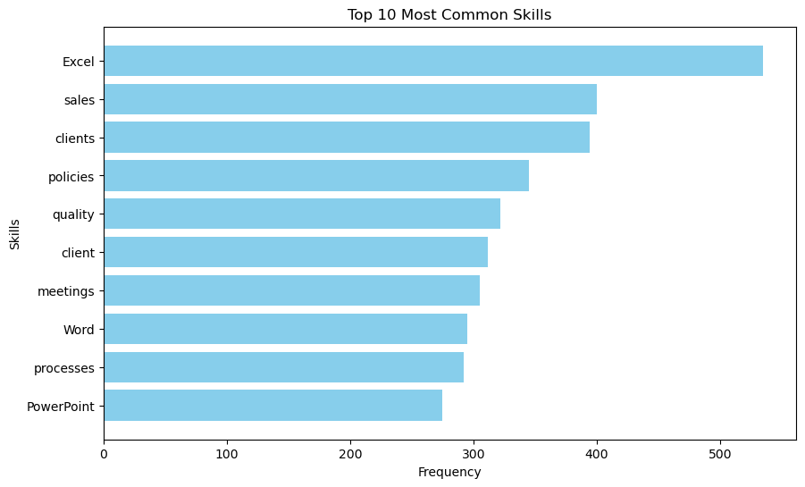

```python
from collections import Counter
import itertools
# Clean and split the 'SKILLS' column into individual skills
skills_list = task1_done1_df['SKILLS'].str.replace('Skills ', '').str.replace('...', '').str.split(', ')
# Flatten the list of lists into a single list of skills
skills_flat_list = list(itertools.chain(*skills_list.dropna()))

# Count the frequency of each skill using Counter
skills_counter = Counter(skills_flat_list)
# Get the 10 most common skills and their counts
most_common_skills = skills_counter.most_common(10)

# Unzip the list of tuples into two lists: one for skills and one for counts
skills, counts = zip(*most_common_skills)

# Plot the most common skills using a horizontal bar chart
plt.figure(figsize=(10, 6))  # Set the size of the plot
plt.barh(skills, counts, color='skyblue')  # Create a horizontal bar chart
plt.xlabel('Frequency')  # Label for the x-axis
plt.ylabel('Skills')  # Label for the y-axis
plt.title('Top 10 Most Common Skills')  # Title of the plot
plt.gca().invert_yaxis()  # Invert the y-axis to show the highest frequency at the top
plt.show()  # Display the plot

#NOTE:
```

Analysis and Interpretation:

The provided code snippet performs data cleaning and analysis to identify the top 10 most common skills from a dataset. Initially, it cleans and splits the 'SKILLS' column, removing specific strings and separating skills by commas. The skills are then flattened into a single list, and their frequencies are counted using the `Counter` class from the `collections` module. The 10 most common skills are extracted and plotted using a horizontal bar chart. The chart visually represents these skills, with the frequency of each skill on the x-axis and the skills themselves on the y-axis, arranged in descending order of frequency. According to the chart, "Excel" is the most frequently mentioned skill, followed by "sales," "clients," "policies," and others. The plot is displayed with the highest frequency skill at the top for easy interpretation.

Q4. Based on the data that you have, could you tell the most active and community helpful applicants are for what position?

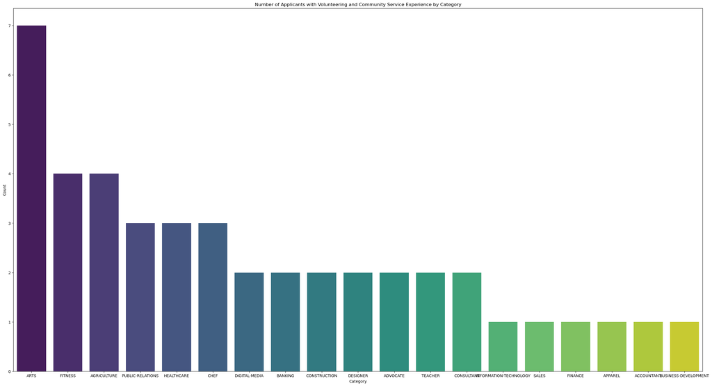

```python
# Filter applicants with community service or volunteering experience
community_volunteers = task1_done1_df[(task1_done1_df['COMMUNITY_SERVICE'] == True) | (task1_done1_df['VOLUNTEERING'] == True)]

# Merge with resume_df based on RESUME_NUMBER and ID
merged_df = pd.merge(community_volunteers, resume_df, left_on='RESUME_NUMBER', right_on='ID')

# Display the relevant columns
result = merged_df[['RESUME_NUMBER', 'Category', 'SKILLS_COUNT', 'COMMUNITY_SERVICE', 'VOLUNTEERING']]
# Count the number of applicants in each category
category_counts = merged_df['Category'].value_counts().reset_index()
category_counts.columns = ['Category', 'Count']

# Plot the data
plt.figure(figsize=(32,17))
sns.barplot(x='Category', y='Count', data=category_counts, palette='viridis')
plt.title('Number of Applicants with Volunteering and Community Service Experience by Category')
plt.xlabel('Category')
plt.show()
```

Analysis and insights: I filtered applicants with community service or volunteering experience and merges this data with another dataset. The plot generated shows the number of applicants in each category. Arts Dominance: "ARTS" category has the highest number of volunteers. Notable Categories: "FITNESS" and "AGRICULTURE" also have significant numbers. Moderate Categories: "PUBLIC-RELATIONS," "HEALTHCARE," and "CHEF" have a balanced number of volunteers. Low Representation: "FINANCE," "APPAREL," "ACCOUNTANT," and "BUSINESS-DEVELOPMENT" have fewer volunteers. This analysis highlights the sectors with the most and least volunteer engagement.

Q5. could you nominate the best job application for each position?

```python
# Merge dataframes on ID/Resume_Number
merged_df = pd.merge(task1_done1_df, resume_df, left_on='RESUME_NUMBER', right_on='ID')

# Define a scoring function to prioritize resumes based on given criteria
def score_resume(row):
    score = 0

    # Qualifications (Assuming non-empty strings are higher qualifications)
    if pd.notna(row['QUALIFICATIONS']) and row['QUALIFICATIONS'].strip():
        score += 10

    # Education Type (Higher education types get more points)
    education_priority = {'PhD': 5, 'Master': 4, 'Bachelor': 3, 'Diploma': 2, 'Certificate': 1}
    score += education_priority.get(row['EDUCATION_TYPE'], 0) * 5

    # School Type (University > College)
    if row['SCHOOL_TYPE'] == 'University':
        score += 5
    elif row['SCHOOL_TYPE'] == 'College':
        score += 3

    # Experience Length (More years of experience get more points)
    try:
        years, months = map(int, row['EXPERIENCE_LENGTH'].replace(' years', '').replace(' months', '').split(','))
        experience_months = years * 12 + months
        score += experience_months / 12  # 1 point per year of experience
    except:
        pass

    # Awards, Community Service, Volunteering, Driver's License Availability
    if row['AWARDS']:
        score += 5
    if row['COMMUNITY_SERVICE']:
        score += 5
    if row['VOLUNTEERING']:
        score += 5
    if row['DRIVERS_LICENSE_AVAILABILITY']:
        score += 5

    # Skills Count (More skills get more points)
    score += row['SKILLS_COUNT']

    return score

# Add a new column 'Score' to the dataframe
merged_df['Score'] = merged_df.apply(score_resume, axis=1)

# Sort the dataframe by 'Category' and 'Score' in descending order
sorted_df = merged_df.sort_values(by=['Category', 'Score'], ascending=[True, False])

# Get the best resume for each category
best_resumes = sorted_df.groupby('Category').first().reset_index()

# Print the best resumes
print(best_resumes[['Category', 'ID', 'Score']])

# Save the best resumes to a new CSV file
best_resumes.to_csv('best_resumes.csv', index=False)
```

```
                  Category        ID       Score
0               ACCOUNTANT  49204385  188.000000
1                 ADVOCATE  19063156  273.000000
2              AGRICULTURE  16507693  128.666667
3                  APPAREL  71767359  151.000000
4                     ARTS  73030450  226.000000
5               AUTOMOBILE  14508237  137.500000
6                 AVIATION  16449694  142.000000
7                  BANKING  21297521  294.000000
8                      BPO  45077654  145.000000
9     BUSINESS-DEVELOPMENT  12230301  207.000000
10                    CHEF  23032276  210.000000
11            CONSTRUCTION  39908485  268.000000
12              CONSULTANT  26167298  265.000000
13                DESIGNER  35990852  200.000000
14           DIGITAL-MEDIA  19861776  218.000000
15             ENGINEERING  12472574  284.000000
16                 FINANCE  24833063  221.000000
17                 FITNESS  34792238  206.000000
18              HEALTHCARE  10062724  216.000000
19                      HR  24508725  204.000000
20  INFORMATION-TECHNOLOGY  19796840  254.000000
21        PUBLIC-RELATIONS  28531493  196.500000
22                   SALES  55097118  139.000000
23                 TEACHER  86597425  145.000000
```

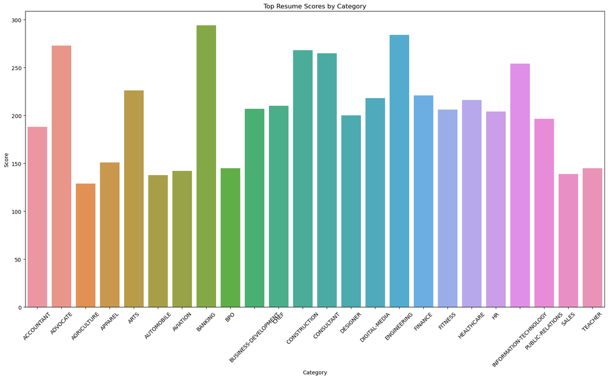

```python
# Plotting
plt.figure(figsize=(16, 10))
sns.barplot(x='Category', y='Score', data=best_resumes)
plt.title('Top Resume Scores by Category')
plt.xlabel('Category')
plt.ylabel('Score')
plt.xticks(rotation=45)
plt.tight_layout()
plt.show()
```

Analsysis and Insights: I merged two dataframes on 'ID/RESUME_NUMBER' and scored the resumes based on a variety of criteria such as qualifications, education type, school type, experience length, awards, community service, volunteering, driver's license availability, and skills count. The resulting dataframe was sorted by category and score, and the best resume for each category was identified.

Q.6 Do you think learning another language could effect the application, support your opinion.

```python
# Filter applicants who have languages listed
applicants_with_languages = task1_done1_df[task1_done1_df['LANGUAGES'].notnull() & (task1_done1_df['LANGUAGES'] != '')]

# Display the filtered applicants
applicants_with_languages.head(50)
```

|  | RESUME_NUMBER | QUALIFICATIONS | EDUCATION_TYPE | SCHOOL_TYPE | EDUCATION_MAJOR | EXPERIENCE_LENGTH | AWARDS | COMMUNITY_SERVICE | VOLUNTEERING | DRIVERS_LICENSE_AVAILABILITY | SKILLS_COUNT | SKILLS | LANGUAGES |
| --- | --- | --- | --- | --- | --- | --- | --- | --- | --- | --- | --- | --- | --- |
| 12 | 23155093 |  |  | College |  | 0 years, 0 months | False | False | False | True | 16 | Skills Management, Administrative Support, ... | Languages Working knowledge of Spanish and ... |
| 38 | 51769822 |  |  | University |  | 0 years, 0 months | False | False | False | False | 27 | Skills Office support: Accounting, bill... | Languages Fluent (speaking, reading, writi... |
| 47 | 26202430 |  | Master | University |  | 0 years, 0 months | False | False | False | True | 13 | Skills Advanced Excel, Access, Word, Visio,... | Languages Portuguese, Spanish and English ... |
| 57 | 28828844 |  |  |  |  | 0 years, 0 months | False | False | False | False | 43 | Skills administrative support, ADP, Benefit... | Languages Able to read, speak and write Spa... |
| 60 | 39081840 |  | Bachelor | University |  | 0 years, 0 months | False | False | False | False | 43 | Skills Payroll · Benefits Administration ·... | Languages Speak fluently in English, Chines... |
| 71 | 14640322 |  | Bachelor | University |  | 0 years, 0 months | False | False | False | True | 1 | Skills Talent Aquisition Onboarding Doc... | Languages English, Hindi, Oriya Person... |
| 75 | 18084150 |  | Master | University |  | 0 years, 0 months | False | False | False | False | 42 | Skills ADP, Benefits, budget, databases, e... | Languages Bilingual (English/Spanish) ... |
| 79 | 29091445 |  | Certificate | College |  | 0 years, 0 months | False | False | False | True | 55 | Skills MS Office (Word, Excel, Outlook ... | Languages Fluent in Spanish and English - R... |
| 92 | 23510685 |  | Master | University |  | 0 years, 0 months | True | False | False | True | 55 | Skills Adobe Acrobat, Analyst, Architect, ... | Languages Mandarin Chinese (native), Spanis... |
| 96 | 15575117 |  | Certificate | College |  | 0 years, 0 months | False | False | False | False | 52 | Skills Administrative, administrative assis... | Languages Fluent in English, and Spanish ... |
| 101 | 28175164 |  | Master | University |  | 0 years, 0 months | False | False | False | False | 4 | Skills PeopleSoft, Microsoft Office Suite, ... | Languages Bilingual: Spanish/English |
| 106 | 24402267 |  | Master |  |  | 3 years, 0 months | False | False | False | True | 13 | Skills HRIS, ISO, Recruitment, Performanc... | Languages English : Advanced and Fluent ... |
| 110 | 37058472 |  | Bachelor | College |  | 0 years, 0 months | False | False | False | False | 1 | Skills AutoCad drafting 3D Rendering Mat... | Languages Fluent in Portuguese and English... |
| 112 | 76010167 |  | Bachelor | University |  | 0 years, 0 months | False | False | False | False | 34 | Skills photo, Advertising, Arabic, artist, ... | Languages English (fluent) Arabic (fluent) ... |
| 115 | 25061645 |  | Bachelor |  |  | 0 years, 0 months | False | False | False | False | 34 | Skills Adobe Creative Suite, Dreamweaver, P... | Languages Bilingual in English and Chinese ... |
| 124 | 85101052 |  | Bachelor | High School |  | 0 years, 0 months | False | False | False | False | 46 | Skills asset management, automation, busine... | Languages English\nHindi\nKannada Skills |
| 128 | 12415691 |  | Certificate | University |  | 0 years, 0 months | False | False | False | True | 68 | Skills Languages\n: C, C++, C#.NET, Java, ... | Languages\n: C, C++, C#.NET, Java, Python, PHP... |
| 140 | 16288901 |  | Bachelor | University |  | 0 years, 0 months | False | False | False | False | 0 |  | Languages Fluent in English and Arabic. ... |
| 143 | 38744475 |  | Bachelor | University |  | 0 years, 0 months | False | False | False | False | 1 | Skills Adobe Creative Suite AutoCAD Pl... | Languages English (Native or bilin... |
| 156 | 37263609 |  | Master | University |  | 0 years, 0 months | False | False | False | True | 1 | Skills Personal: Rhino; Revit; CInema 4D; ... | Languages Bilingual Spanish/English Fluen... |
| 159 | 54201930 |  | Bachelor |  |  | 0 years, 0 months | False | False | False | True | 44 | Skills Marketing, Clients, Ads, Basis, Sale... | Languages Spanish - Native Speaker \| [AND] ... |
| 162 | 11958994 |  |  |  |  | 0 years, 0 months | False | False | False | True | 37 | Skills Adobe, attorney, benefits, call cent... | Languages Bilingual, Greek and English, ora... |
| 166 | 34657584 |  |  | College |  | 14 years, 6 months | False | False | False | True | 20 | Skills 3D, Adobe, Adobe-Photoshop, AutoCAD ... | Languages Known English (IELTS-4.5), Hindi, Ma... |
| 168 | 18979238 |  | Diploma | High School |  | 0 years, 0 months | False | False | False | True | 36 | Skills arts, blueprint reading, bridges, Co... | Languages Can read and speak in German and ... |
| 170 | 22675694 |  | Diploma | High School |  | 2 years, 0 months | False | False | True | False | 2 | Skills Desktop Publishing Software: Photo... | Languages I am able to comfortably speak a... |
| 202 | 24285142 | Accomplished Graphic Designer with over 15 ye... |  | University |  | 0 years, 0 months | True | False | False | True | 72 | Skills 3D, acrylics, Acrobat, Adobe, Dreamw... | Languages Spanish: Read, write, speak fluen... |
| 210 | 18795567 |  | Master |  |  | 31 years, 4 months | True | False | False | True | 41 | Skills 3D, 3D Design, Adobe Creative Suite,... | Languages Chinese - Fluent, Japanese - Limi... |
| 215 | 37695494 |  | Bachelor | University |  | 0 years, 0 months | False | False | False | False | 22 | Skills 3D, Adobe Creative Suite, photo, ad,... | Languages Fluent in multiple languages, Eng... |
| 240 | 68460556 |  | Certificate | University |  | 0 years, 0 months | False | False | False | False | 17 | Skills American Sign Language, Excellent co... | Languages Fluent in American Sign Language ... |
| 242 | 25959103 |  | Master |  |  | 0 years, 0 months | False | False | False | False | 35 | Skills Arabic, Back-up, budgets, hardware, ... | Languages Arabic (fluent) Skills |
| 255 | 10839851 |  | Diploma |  |  | 0 years, 0 months | False | False | False | False | 39 | Skills Desktops, Ethernet cables Ci... | Languages Fluent in Dari, Dutch, and Russian |
| 263 | 29051656 |  | Bachelor | University |  | 0 years, 0 months | False | False | False | False | 0 |  | Languages : \n\n·SQL*PLUS, PL/SQL, UNIX Shell ... |
| 268 | 28697203 |  | Master | University |  | 0 years, 0 months | False | False | False | False | 29 | Skills Agile methodology Project man... | Languages Fluent in Spanish |
| 290 | 51639418 |  | PhD | University |  | 0 years, 0 months | True | False | False | True | 60 | Skills ADABAS, AIX, analyst, Application De... | Languages Fully bilingual in English and Sp... |
| 291 | 20674668 |  | Bachelor | College |  | 0 years, 0 months | False | False | False | False | 3 | Skills in theming, as well. Driven to provide ... | Languages and Databases: SQL, PL/SQL, Oracle ... |
| 293 | 18159866 |  |  | University |  | 0 years, 0 months | False | False | False | False | 15 | Skills •Experienced in strategic planning ... | Languages Bilingual - Fully fluent in Engli... |
| 302 | 31111279 | Certification B.A : Foreign Languages ... | Certificate | College |  | 0 years, 0 months | False | False | False | True | 4 | Skills Manage departmental budget for all... | Languages and Literatures 1997 VPI & S... |
| 342 | 22408666 |  | Bachelor | College |  | 0 years, 0 months | False | False | False | False | 16 | Skills Increase, Training, Coaching, Teachi... | Languages Teaching Experience; Bilingual Fl... |
| 357 | 35421497 |  | Bachelor | College |  | 0 years, 0 months | False | False | False | False | 2 | Skills Creative at lesson planning and ha... | Languages Trilingual in English, Russian... |
| 413 | 25588694 | Certification in Secondary level Spanish ... | Master | High School |  | 0 years, 0 months | False | False | False | True | 1 | Skills Strong interpersonal skills Smart ... | Languages program. Chaperoned High School Eur... |
| 421 | 32067700 |  | Bachelor | University |  | 0 years, 0 months | False | False | False | False | 36 | Skills MS Office Interpersonal Commu... | Languages Turkish \nNative \nEnglish \nNati... |
| 427 | 12587973 |  | Diploma | High School |  | 0 years, 0 months | False | False | False | False | 47 | Skills agency, budgeting, budgets, business... | Languages Fluent in English and Spanish ... |
| 446 | 73448369 |  | Certificate | High School |  | 0 years, 0 months | False | False | False | False | 1 | Skills Fast data entry Spreadsheet table... | Languages English - Good ( Read Write Speak... |
| 452 | 13967854 |  |  | College |  | 0 years, 0 months | False | False | False | False | 3 | Skills Trained in indicators of child... | Languages Bilingual Spanish/English ... |
| 468 | 20324037 |  | Diploma | University |  | 0 years, 0 months | False | False | False | False | 1 | Skills Customer Service Self Starter T... | Languages English 90% Portugues 60% ... |
| 475 | 74126637 |  | Bachelor | University |  | 0 years, 0 months | False | False | False | False | 12 | Skills Development for CPS Conservatorship cer... | Languages Bilingual Spanish/English |
| 477 | 24410405 |  | Bachelor | University |  | 42 years, 4 months | False | False | False | False | 39 | Skills DOMS applications, AS/400, Microsoft a... | Languages English\nFluent Highlights ... |
| 484 | 18997135 |  | Bachelor | University |  | 0 years, 0 months | False | False | False | False | 14 | Skills Chinese, Conferences, Clients, Engl... | Languages Fluent in English and Chinese. ... |
| 487 | 13909762 |  | Certificate | College |  | 0 years, 0 months | False | False | False | True | 46 | Skills Greet, Telephone Customer Service, ... | Languages Bilingual English/Spanish writte... |
| 496 | 37560528 |  | Diploma | College |  | 0 years, 0 months | False | False | False | False | 8 | Skills Microsoft Office: Word, Excel, Power... | Languages Bilingual Fluent in Spanish ... |

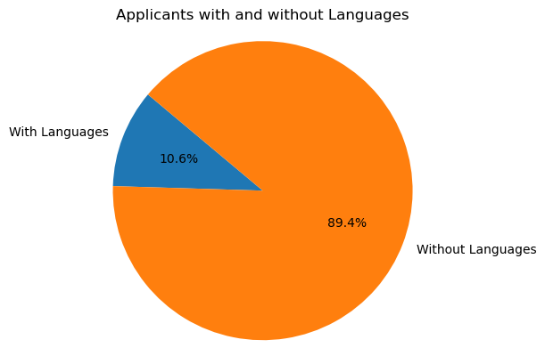

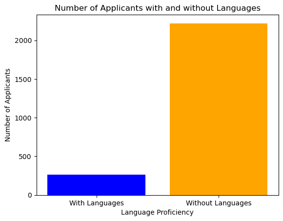

```python
# Count the number of applicants with and without languages listed
applicants_with_languages = task1_done1_df[task1_done1_df['LANGUAGES'].notnull() & (task1_done1_df['LANGUAGES'] != '')]
applicants_without_languages = task1_done1_df[task1_done1_df['LANGUAGES'].isnull() | (task1_done1_df['LANGUAGES'] == '')]

# Calculate the total number of applicants
total_applicants = len(task1_done1_df)

# Calculate the number of applicants with and without languages
num_with_languages = len(applicants_with_languages)
num_without_languages = len(applicants_without_languages)

# Create a pie chart to visualize the proportion of applicants with and without languages
labels = ['With Languages', 'Without Languages']
sizes = [num_with_languages, num_without_languages]
plt.pie(sizes, labels=labels, autopct='%1.1f%%', startangle=140)
plt.axis('equal')
plt.title('Applicants with and without Languages')
plt.show()

# Create a bar plot to compare the number of applicants with and without languages
plt.bar(['With Languages', 'Without Languages'], [num_with_languages, num_without_languages], color=['blue', 'orange'])
plt.xlabel('Language Proficiency')
plt.ylabel('Number of Applicants')
plt.title('Number of Applicants with and without Languages')
plt.show()
```

Analysis and Insights: The pie chart titled "Applicants with and without Languages" visually represents the proportion of applicants who have listed language skills compared to those who have not. The chart indicates that a significant majority (89.4%) of applicants do not have languages listed, while only a small portion (10.6%) have included languages in their application. The pie chart technique was used here to provide a clear and immediate visual understanding of the distribution between the two groups. By using distinct colors (blue for "With Languages" and orange for "Without Languages"), the differences are easily distinguishable, making it simple to comprehend the data at a glance. This method effectively communicates the disparity in language proficiency among applicants, which could be crucial for assessing the overall skill set and readiness of the applicant pool for roles requiring language skills.

Q7. Give a full statistical description for all numrical data columns including all insights and needed figures to visualize them.

```python
import pandas as pd

# Function to convert experience length to months
def experience_length_to_months(exp_length):
    if pd.isna(exp_length):
        return None
    if 'years' in exp_length and 'months' in exp_length:
        years, months = exp_length.split(' years, ')
        months = months.replace(' months', '')
        return int(years) * 12 + int(months)
    elif 'years' in exp_length:
        return int(exp_length.replace(' years', '')) * 12
    elif 'months' in exp_length:
        return int(exp_length.replace(' months', ''))
    else:
        return None

# Apply function to convert EXPERIENCE_LENGTH to months
task1_done1_df['EXPERIENCE_LENGTH'] = task1_done1_df['EXPERIENCE_LENGTH'].apply(experience_length_to_months)

# Convert EXPERIENCE_LENGTH to numeric type
task1_done1_df['EXPERIENCE_LENGTH'] = pd.to_numeric(task1_done1_df['EXPERIENCE_LENGTH'], errors='coerce')

# Print the first few rows to verify the changes
print(task1_done1_df[['EXPERIENCE_LENGTH']].head())
#NOTE: This is the experience length in months
```

```
   EXPERIENCE_LENGTH
0                281
1                  0
2                  0
3                 71
4                256
```

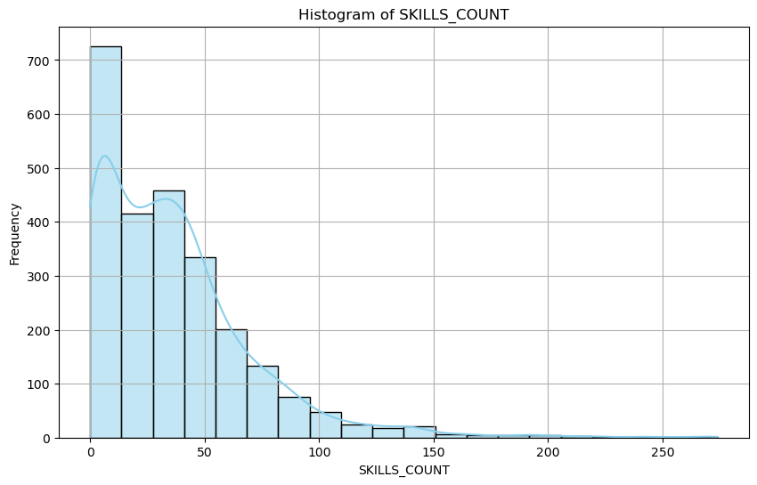

[output not shown]

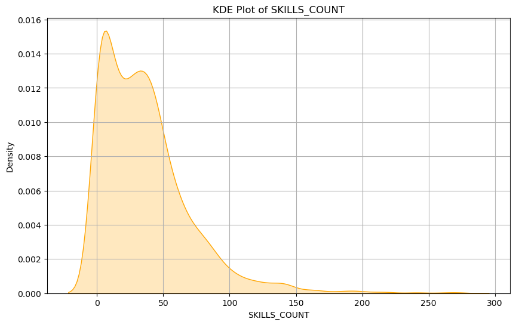

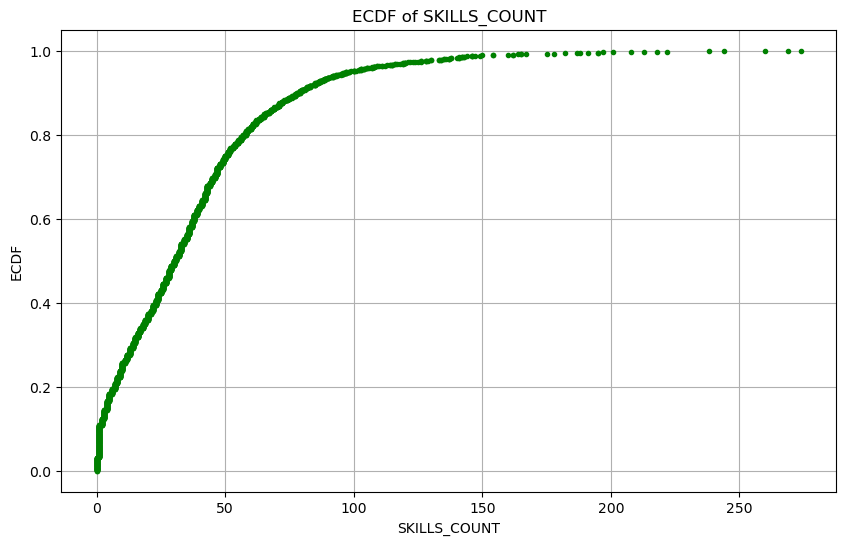

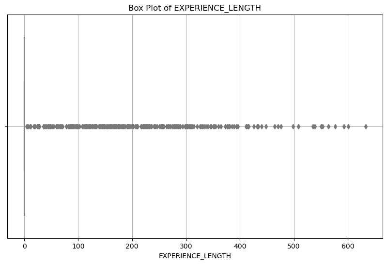

[output not shown]

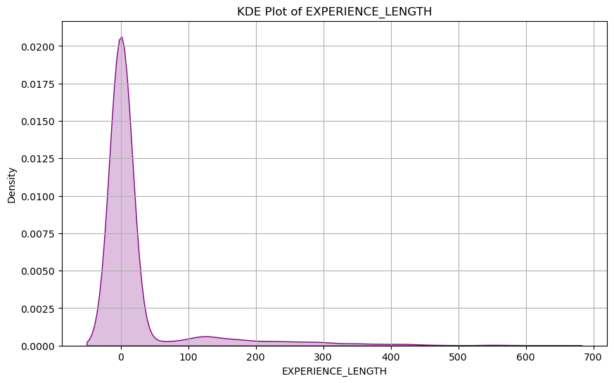

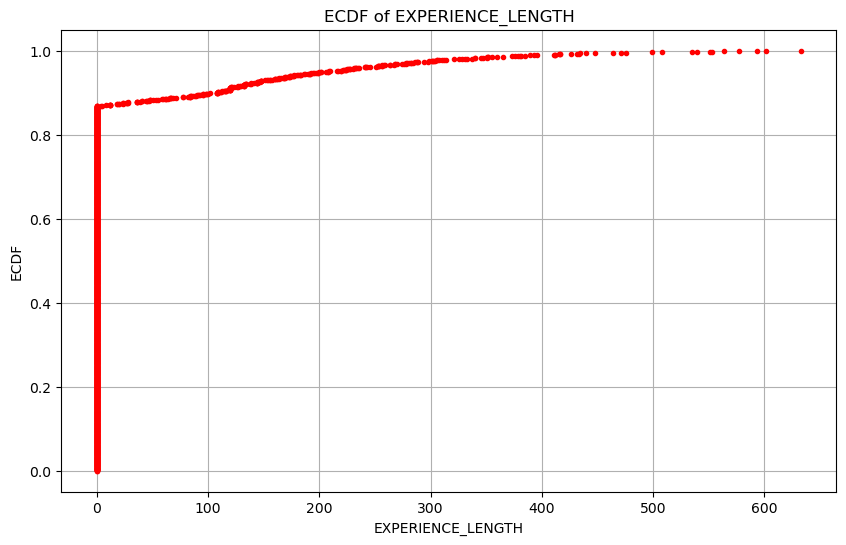

```
Descriptive Statistics for SKILLS_COUNT:
count    2484.000000
mean       36.620773
std        34.368996
min         0.000000
25%        10.000000
50%        30.500000
75%        50.000000
max       274.000000
Name: SKILLS_COUNT, dtype: float64

Descriptive Statistics for EXPERIENCE_LENGTH:
count    2484.000000
mean       25.637279
std        80.496987
min         0.000000
25%         0.000000
50%         0.000000
75%         0.000000
max       633.000000
Name: EXPERIENCE_LENGTH, dtype: float64
```

```python
import matplotlib.pyplot as plt
import seaborn as sns
import numpy as np

# Descriptive statistics for SKILLS_COUNT
skills_stats = task1_done1_df['SKILLS_COUNT'].describe()

# Histogram of SKILLS_COUNT
plt.figure(figsize=(10, 6))
sns.histplot(task1_done1_df['SKILLS_COUNT'], bins=20, kde=True, color='skyblue')
plt.title('Histogram of SKILLS_COUNT')
plt.xlabel('SKILLS_COUNT')
plt.ylabel('Frequency')
plt.grid(True)
plt.show()

# KDE plot of SKILLS_COUNT
plt.figure(figsize=(10, 6))
sns.kdeplot(task1_done1_df['SKILLS_COUNT'], color='orange', shade=True)
plt.title('KDE Plot of SKILLS_COUNT')
plt.xlabel('SKILLS_COUNT')
plt.ylabel('Density')
plt.grid(True)
plt.show()

# ECDF of SKILLS_COUNT
def ecdf(data):
    n = len(data)
    x = np.sort(data)
    y = np.arange(1, n+1) / n
    return x, y

x_skills, y_skills = ecdf(task1_done1_df['SKILLS_COUNT'])
plt.figure(figsize=(10, 6))
plt.plot(x_skills, y_skills, marker='.', linestyle='none', color='green')
plt.title('ECDF of SKILLS_COUNT')
plt.xlabel('SKILLS_COUNT')
plt.ylabel('ECDF')
plt.grid(True)
plt.show()

# Descriptive statistics for EXPERIENCE_LENGTH
exp_stats = task1_done1_df['EXPERIENCE_LENGTH'].describe()

# Box plot of EXPERIENCE_LENGTH
plt.figure(figsize=(10, 6))
sns.boxplot(x='EXPERIENCE_LENGTH', data=task1_done1_df, color='lightblue')
plt.title('Box Plot of EXPERIENCE_LENGTH')
plt.xlabel('EXPERIENCE_LENGTH')
plt.grid(True)
plt.show()

# KDE plot of EXPERIENCE_LENGTH
plt.figure(figsize=(10, 6))
sns.kdeplot(task1_done1_df['EXPERIENCE_LENGTH'], color='purple', shade=True)
plt.title('KDE Plot of EXPERIENCE_LENGTH')
plt.xlabel('EXPERIENCE_LENGTH')
plt.ylabel('Density')
plt.grid(True)
plt.show()

# ECDF of EXPERIENCE_LENGTH
x_exp, y_exp = ecdf(task1_done1_df['EXPERIENCE_LENGTH'].dropna())
plt.figure(figsize=(10, 6))
plt.plot(x_exp, y_exp, marker='.', linestyle='none', color='red')
plt.title('ECDF of EXPERIENCE_LENGTH')
plt.xlabel('EXPERIENCE_LENGTH')
plt.ylabel('ECDF')
plt.grid(True)
plt.show()

# Print descriptive statistics for SKILLS_COUNT and EXPERIENCE_LENGTH
print("Descriptive Statistics for SKILLS_COUNT:")
print(skills_stats)
print("\nDescriptive Statistics for EXPERIENCE_LENGTH:")
print(exp_stats)
```

Insights and analysis:

ECDF of SKILLS_COUNT: The Empirical Cumulative Distribution Function (ECDF) shows that nearly 80% of the population has less than 50 skills, highlighting a concentration of lower skill counts among the surveyed group.

EXPERIENCE_LENGTH Distribution: The box plot of experience length is very tight around a small range, with most of the data clustered close to 0, suggesting that most individuals have minimal experience. The KDE plot reinforces this observation, showing a sharp peak near zero.

ECDF of EXPERIENCE_LENGTH: The sharp rise at the beginning of the ECDF graph indicates that a large majority of the individuals have very short lengths of experience, corroborating what is seen in the box plot and KDE plot.

Q8. Give a full statistical description for the categorical data columns that can be descriped including all insights and needed figures to visualize them.

# note: use_univariate with catergircal

```python
task1_done1_df.tail(40)
```

|  | RESUME_NUMBER | QUALIFICATIONS | EDUCATION_TYPE | SCHOOL_TYPE | EDUCATION_MAJOR | EXPERIENCE_LENGTH | AWARDS | COMMUNITY_SERVICE | VOLUNTEERING | DRIVERS_LICENSE_AVAILABILITY | SKILLS_COUNT | SKILLS | LANGUAGES |
| --- | --- | --- | --- | --- | --- | --- | --- | --- | --- | --- | --- | --- | --- |
| 2444 | 16850314 |  | Bachelor | University |  | 0 | False | False | False | True | 69 | Skills Work History ST... |  |
| 2445 | 11959428 |  |  | University |  | 0 | False | False | False | False | 0 |  |  |
| 2446 | 10395944 |  | Certificate | College |  | 0 | False | False | False | False | 23 | Skills Great People Skills Microsof... |  |
| 2447 | 10189110 |  | Certificate | College |  | 0 | True | False | False | True | 54 | Skills x Expedite / AOG / Logistics\n ... |  |
| 2448 | 10567764 |  | Certificate | College |  | 0 | True | False | False | True | 19 | Skills blueprints, C, charts, color, office... |  |
| 2449 | 30148777 |  | Master | College |  | 0 | False | False | False | False | 46 | Skills accounts payable, accounts receivabl... |  |
| 2450 | 24544244 |  | Bachelor | University |  | 0 | False | False | False | True | 79 | Skills Customer service specialis... |  |
| 2451 | 19284293 |  | Certificate | University |  | 0 | True | False | False | True | 3 | Skills Flight test management UAS op... |  |
| 2452 | 11752500 |  | Bachelor | University |  | 0 | False | False | False | False | 60 | Skills Troubleshooting Problem Res... |  |
| 2453 | 31536294 |  | Bachelor | University |  | 0 | False | False | False | False | 0 |  |  |
| 2454 | 22442947 |  | Diploma | High School |  | 0 | False | False | False | False | 13 | Skills Strategic planning Team buildi... |  |
| 2455 | 27512470 |  | Diploma | High School |  | 0 | False | False | False | False | 38 | Skills Account Management, Calendaring, Cl... |  |
| 2456 | 14874322 |  |  | College |  | 0 | False | False | False | False | 7 | Skills customer service, delivery, document... |  |
| 2457 | 23464505 |  | Master | University |  | 0 | False | False | False | False | 53 | Skills Server-side technologies : servl... |  |
| 2458 | 12504278 |  |  | University |  | 0 | False | False | False | False | 21 | Skills accounting, accounting system, custo... |  |
| 2459 | 58048626 |  | Master | University |  | 0 | False | False | False | True | 44 | Skills accountancy, accounting system, agen... | Languages Bilingual in English and Spanish.... |
| 2460 | 15684810 | Certification : NAS North Island , 2003... |  | College | Major: Criminal Justice *Introduction to Crimi... | 0 | False | False | False | True | 72 | Skills Security, Aviation, Class, Comprehen... |  |
| 2461 | 17694572 |  |  |  |  | 0 | False | False | False | False | 1 | Skills Clinical/Administrative Skills Ph... |  |
| 2462 | 22168194 |  | Diploma | College |  | 0 | False | False | False | False | 86 | Skills Microsoft Office Art Clients... |  |
| 2463 | 29595906 |  | Diploma | College |  | 0 | False | False | False | True | 10 | Skills Dependable Fast Learner Trustwo... |  |
| 2464 | 77626587 |  | Bachelor | University |  | 0 | False | False | False | False | 17 | Skills Account Management, conflict resolut... |  |
| 2465 | 98389424 |  | Bachelor | University |  | 0 | True | False | False | False | 48 | Skills Active Directory, streamline, ADP, a... |  |
| 2466 | 38663892 |  | Bachelor | University |  | 0 | False | False | False | True | 49 | Skills accounting, administrative, administ... | Languages Languge_ English Additional ... |
| 2467 | 17152392 |  |  | College |  | 0 | False | False | False | True | 51 | Skills streamline, balance, budgets, Busine... | Languages Fluent in Spanish Skills |
| 2468 | 49646155 |  | Bachelor | University |  | 0 | False | False | False | False | 13 | Skills balance budgets, contracts, deliver... |  |
| 2469 | 33627938 | Certification (SAPPC) Security Fundamentals P... | Master | University |  | 0 | False | False | False | True | 0 |  |  |
| 2470 | 12904972 | Certifications Master Certificate in Six S... | Master | University |  | 0 | False | False | False | True | 82 | Skills Fiber Optics Repair Technical Sk... | Languages Read/ Write/ and Conversational ... |
| 2471 | 12239749 | Certifications PRAXIS: Principles of Learn... | Master | University |  | 171 | False | False | False | False | 4 | Skills Advanced vocabulary and reading com... |  |
| 2472 | 16279537 |  | Bachelor | University |  | 0 | False | False | False | True | 4 | Skills Ability to lead, motivate and buil... |  |
| 2473 | 17008356 |  |  | University |  | 0 | False | False | False | False | 42 | Skills B2B Strategic Selling Business De... |  |
| 2474 | 28020046 |  | Bachelor | University |  | 0 | False | False | False | False | 7 | Skills Client Relations Software: Dynamics... | Languages English - Fluent (Read, Write an... |
| 2475 | 25625173 |  |  | University |  | 0 | False | False | False | True | 48 | Skills AIA, business plans, hardware, conte... |  |
| 2476 | 29534737 |  | Master | College |  | 0 | True | False | False | True | 19 | Skills blue print reading, blueprints, cali... |  |
| 2477 | 17655479 |  | Diploma | High School |  | 0 | False | False | False | False | 12 | Skills delivery, forklifts, inventory, ISO... |  |
| 2478 | 12043694 | Certifications CompTIA A+ Certified Pursui... | Certificate | University |  | 0 | False | False | False | False | 104 | Skills Proven excellence with budgets, schedul... |  |
| 2479 | 99416532 | Certified by the USPS and handled over ... |  | College |  | 0 | False | False | False | True | 3 | Skills Dedication to customer service, of... |  |
| 2480 | 24589765 |  | Bachelor | University |  | 0 | False | False | False | True | 68 | Skills Work History 01/... |  |
| 2481 | 31605080 |  |  | University |  | 0 | False | False | False | False | 17 | Skills Active Directory, Hardware, Customer... |  |
| 2482 | 21190805 |  | Bachelor | University |  | 0 | False | False | False | True | 40 | Skills Adobe, CPR, clients, customer satisf... |  |
| 2483 | 37473139 |  | Bachelor | University |  | 0 | False | False | False | True | 69 | Skills Work History ST... |  |

```python
# Descriptive statistics for categorical data
categorical_columns = ['EDUCATION_TYPE', 'SCHOOL_TYPE', 'EDUCATION_MAJOR', 'AWARDS', 'COMMUNITY_SERVICE', 'VOLUNTEERING', 'DRIVERS_LICENSE_AVAILABILITY']
descriptive_stats = task1_done1_df[categorical_columns].describe(include='all')
```

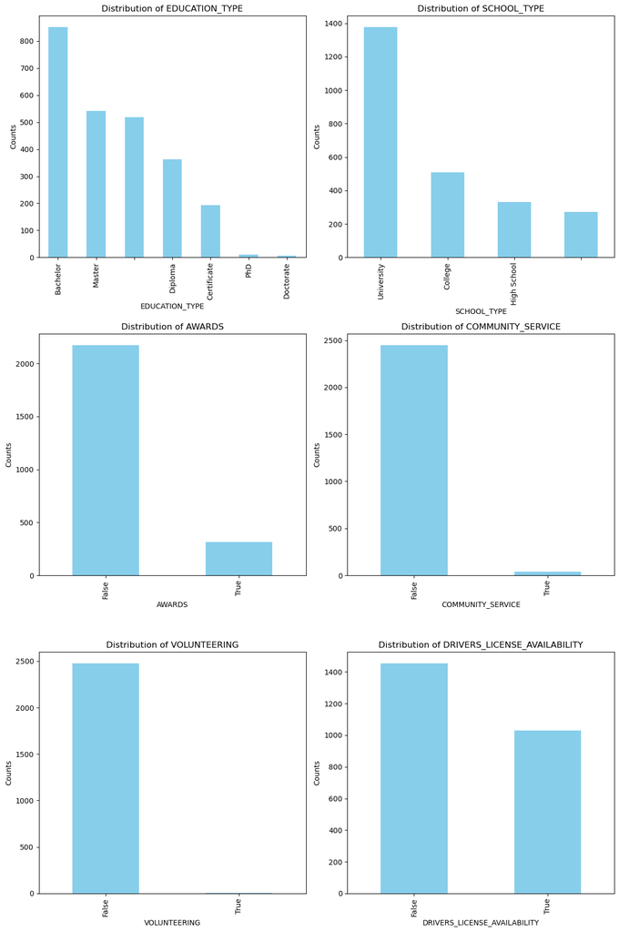

```python
# Generating figures for visualization
fig, axs = plt.subplots(3, 2, figsize=(12, 18))

for i, col in enumerate(['EDUCATION_TYPE', 'SCHOOL_TYPE', 'AWARDS', 'COMMUNITY_SERVICE', 'VOLUNTEERING', 'DRIVERS_LICENSE_AVAILABILITY']):
    ax = axs[i//2, i%2]
    task1_done1_df[col].value_counts(dropna=False).plot(kind='bar', ax=ax, color='skyblue')
    ax.set_title(f'Distribution of {col}')
    ax.set_xlabel(col)
    ax.set_ylabel('Counts')

plt.tight_layout()
plt.show()
```

Analysis and Insights: Education Type: Most people have a Bachelor's degree, followed by those with a Master's and Diploma. Very few have PhDs or Doctorates, indicating higher education beyond a Master's is less common in this dataset.

Awards: A vast majority have not received awards, suggesting either a highly selective awarding process or a group with lesser engagement in award-winning activities.

Community Service: Similar to the Awards distribution, most individuals have not participated in community service, which might indicate either lack of opportunities or interest in such activities within this group.

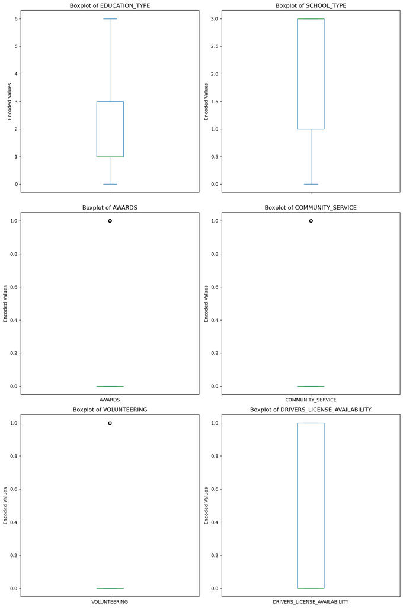

```python
# Generating boxplots for categorical data, although not ideal, we can still use them for binary categories
fig, axs = plt.subplots(3, 2, figsize=(12, 18))

for i, col in enumerate(['EDUCATION_TYPE', 'SCHOOL_TYPE', 'AWARDS', 'COMMUNITY_SERVICE', 'VOLUNTEERING', 'DRIVERS_LICENSE_AVAILABILITY']):
    ax = axs[i//2, i%2]
    # We must convert True/False to 1/0 for plotting purposes
    if task1_done1_df[col].dtype == bool:
        task1_done1_df[col].astype(int).plot(kind='box', ax=ax)
    else:
        # For nominal data with more than two categories, we assign each category a numeric code
        task1_done1_df[col].astype('category').cat.codes.plot(kind='box', ax=ax)
    ax.set_title(f'Boxplot of {col}')
    ax.set_ylabel('Encoded Values')

plt.tight_layout()
plt.show()
```